# Happiness Report

Damian Brown

10/27/2020

## World Happiness Report

This data was collected from Kaggle. This data is a report of happiness measurements from different countries around the world. There are mulitple variables that were collected from each country such as ‘Happines Score’, "Life Expectancy’, ‘Trust of Government’, and more. There are a total of 5 dataset, each being a different year; 2015, 2016, 2017, 2018, 2019.

In this project I plan to import the data files, tidy the data, and combine all data into one main dataset.

### Happiness Data 2015 Report

| Country | Region | Happiness.Rank | Happiness.Score | Standard.Error | Economy..GDP.per.Capita. | Family | Health..Life.Expectancy. | Freedom | Trust..Government.Corruption. | Generosity | Dystopia.Residual |
| --- | --- | --- | --- | --- | --- | --- | --- | --- | --- | --- | --- |
| Switzerland | Western Europe | 1 | 7.587 | 0.03411 | 1.39651 | 1.34951 | 0.94143 | 0.66557 | 0.41978 | 0.29678 | 2.51738 |
| Iceland | Western Europe | 2 | 7.561 | 0.04884 | 1.30232 | 1.40223 | 0.94784 | 0.62877 | 0.14145 | 0.43630 | 2.70201 |
| Denmark | Western Europe | 3 | 7.527 | 0.03328 | 1.32548 | 1.36058 | 0.87464 | 0.64938 | 0.48357 | 0.34139 | 2.49204 |
| Norway | Western Europe | 4 | 7.522 | 0.03880 | 1.45900 | 1.33095 | 0.88521 | 0.66973 | 0.36503 | 0.34699 | 2.46531 |
| Canada | North America | 5 | 7.427 | 0.03553 | 1.32629 | 1.32261 | 0.90563 | 0.63297 | 0.32957 | 0.45811 | 2.45176 |
| Finland | Western Europe | 6 | 7.406 | 0.03140 | 1.29025 | 1.31826 | 0.88911 | 0.64169 | 0.41372 | 0.23351 | 2.61955 |

|  | Country | Region | Happiness.Rank | Happiness.Score | Standard.Error | Economy..GDP.per.Capita. | Family | Health..Life.Expectancy. | Freedom | Trust..Government.Corruption. | Generosity | Dystopia.Residual |
| --- | --- | --- | --- | --- | --- | --- | --- | --- | --- | --- | --- | --- |
|  | Length:158 | Length:158 | Min. : 1.00 | Min. :2.839 | Min. :0.01848 | Min. :0.0000 | Min. :0.0000 | Min. :0.0000 | Min. :0.0000 | Min. :0.00000 | Min. :0.0000 | Min. :0.3286 |
|  | Class :character | Class :character | 1st Qu.: 40.25 | 1st Qu.:4.526 | 1st Qu.:0.03727 | 1st Qu.:0.5458 | 1st Qu.:0.8568 | 1st Qu.:0.4392 | 1st Qu.:0.3283 | 1st Qu.:0.06168 | 1st Qu.:0.1506 | 1st Qu.:1.7594 |
|  | Mode :character | Mode :character | Median : 79.50 | Median :5.232 | Median :0.04394 | Median :0.9102 | Median :1.0295 | Median :0.6967 | Median :0.4355 | Median :0.10722 | Median :0.2161 | Median :2.0954 |
|  | NA | NA | Mean : 79.49 | Mean :5.376 | Mean :0.04788 | Mean :0.8461 | Mean :0.9910 | Mean :0.6303 | Mean :0.4286 | Mean :0.14342 | Mean :0.2373 | Mean :2.0990 |
|  | NA | NA | 3rd Qu.:118.75 | 3rd Qu.:6.244 | 3rd Qu.:0.05230 | 3rd Qu.:1.1584 | 3rd Qu.:1.2144 | 3rd Qu.:0.8110 | 3rd Qu.:0.5491 | 3rd Qu.:0.18025 | 3rd Qu.:0.3099 | 3rd Qu.:2.4624 |
|  | NA | NA | Max. :158.00 | Max. :7.587 | Max. :0.13693 | Max. :1.6904 | Max. :1.4022 | Max. :1.0252 | Max. :0.6697 | Max. :0.55191 | Max. :0.7959 | Max. :3.6021 |

Without showing the other 4 tables for the remaining dataset I can say that the other tables follow the same structure with a minor exception that we will see later.

The main difference between each dataset is the name of each column and the order in which the variables are listed. There are a few “extra” columns that we can deem unecessary for this project.

### Data Cleaning

My first steps for cleaning this data will be to create new datasets that contain only the variables we are interested in. Next I will add a column to each dataset with the year of the observations so that when we combine all of the dataset together we can distinguish each observation from the other. Following that I will organize the variables into a determined order and then rename each column for uniformity.

| Country | Region | Year | Happiness Ranking | Happiness Score | Life Expectancy | GDP per Capita | Generosity | Freedom | Trust in Government |
| --- | --- | --- | --- | --- | --- | --- | --- | --- | --- |
| Switzerland | Western Europe | 2015 | 1 | 7.587 | 0.94143 | 1.39651 | 0.29678 | 0.66557 | 0.41978 |
| Iceland | Western Europe | 2015 | 2 | 7.561 | 0.94784 | 1.30232 | 0.43630 | 0.62877 | 0.14145 |
| Denmark | Western Europe | 2015 | 3 | 7.527 | 0.87464 | 1.32548 | 0.34139 | 0.64938 | 0.48357 |
| Norway | Western Europe | 2015 | 4 | 7.522 | 0.88521 | 1.45900 | 0.34699 | 0.66973 | 0.36503 |
| Canada | North America | 2015 | 5 | 7.427 | 0.90563 | 1.32629 | 0.45811 | 0.63297 | 0.32957 |
| Finland | Western Europe | 2015 | 6 | 7.406 | 0.88911 | 1.29025 | 0.23351 | 0.64169 | 0.41372 |

This data is looking fairly good to start considering combining them together for the main and final dataset, however there is a pretty big discrepancy. Can you spot it?

Below is a protion for the 2019 Happiness Report Dataset

| Country | Year | Happiness Ranking | Happiness Score | Life Expectancy | GDP per Capita | Generosity | Freedom | Trust in Government |
| --- | --- | --- | --- | --- | --- | --- | --- | --- |
| Finland | 2019 | 1 | 7.769 | 0.986 | 1.340 | 0.153 | 0.596 | 0.393 |
| Denmark | 2019 | 2 | 7.600 | 0.996 | 1.383 | 0.252 | 0.592 | 0.410 |
| Norway | 2019 | 3 | 7.554 | 1.028 | 1.488 | 0.271 | 0.603 | 0.341 |
| Iceland | 2019 | 4 | 7.494 | 1.026 | 1.380 | 0.354 | 0.591 | 0.118 |
| Netherlands | 2019 | 5 | 7.488 | 0.999 | 1.396 | 0.322 | 0.557 | 0.298 |
| Switzerland | 2019 | 6 | 7.480 | 1.052 | 1.452 | 0.263 | 0.572 | 0.343 |

It turns out that 2017, 2018, and 2019 are missing the variable ‘Region’. This is, in my opinion, a major variable that is needed for every observation in the final dataset.

Now we can see that the Region has been added to the datasets and we can start working to combine them all into one. First let’s check the summary of each dataset to ensure each variable is the same datatype.

|  | Country | Region | Year | Happiness Ranking | Happiness Score | Life Expectancy | GDP per Capita | Generosity | Freedom | Trust in Government |
| --- | --- | --- | --- | --- | --- | --- | --- | --- | --- | --- |
|  | Length:158 | Length:158 | Min. :2018 | Min. : 1.00 | Min. :2.905 | Min. :0.0000 | Min. :0.0240 | Min. :0.0000 | Min. :0.0000 | Length:158 |
|  | Class :character | Class :character | 1st Qu.:2018 | 1st Qu.: 39.25 | 1st Qu.:4.460 | 1st Qu.:0.4300 | 1st Qu.:0.6255 | 1st Qu.:0.1085 | 1st Qu.:0.3560 | Class :character |
|  | Mode :character | Mode :character | Median :2018 | Median : 78.50 | Median :5.378 | Median :0.6615 | Median :0.9595 | Median :0.1725 | Median :0.4735 | Mode :character |
|  | NA | NA | Mean :2018 | Mean : 78.20 | Mean :5.387 | Mean :0.6039 | Mean :0.8973 | Mean :0.1813 | Mean :0.4529 | NA |
|  | NA | NA | 3rd Qu.:2018 | 3rd Qu.:116.75 | 3rd Qu.:6.171 | 3rd Qu.:0.7798 | 3rd Qu.:1.1947 | 3rd Qu.:0.2427 | 3rd Qu.:0.5773 | NA |
|  | NA | NA | Max. :2018 | Max. :156.00 | Max. :7.632 | Max. :1.0300 | Max. :2.0960 | Max. :0.5980 | Max. :0.7240 | NA |
|  | NA | NA | NA’s :8 | NA’s :8 | NA’s :8 | NA’s :8 | NA’s :8 | NA’s :8 | NA’s :8 | NA |

As mentioned before the 2018 dataset has become a problem that needs to be addressed. Currently the datatype for the ‘Trust in Government’ is character. This will prevent us from combining the data so we much correct this first. I will exctract the vector, change the vector to a numeric value, and then insert the vector back into the dataset.

We can see that the datatype for ‘Trust in Government’ has been changed to a numeric value.

|  | Country | Region | Year | Happiness Ranking | Happiness Score | Life Expectancy | GDP per Capita | Generosity | Freedom | Trust in Government |
| --- | --- | --- | --- | --- | --- | --- | --- | --- | --- | --- |
|  | Length:158 | Length:158 | Min. :2018 | Min. : 1.00 | Min. :2.905 | Min. :0.0000 | Min. :0.0240 | Min. :0.0000 | Min. :0.0000 | Min. :0.0000 |
|  | Class :character | Class :character | 1st Qu.:2018 | 1st Qu.: 39.25 | 1st Qu.:4.460 | 1st Qu.:0.4300 | 1st Qu.:0.6255 | 1st Qu.:0.1085 | 1st Qu.:0.3560 | 1st Qu.:0.0510 |
|  | Mode :character | Mode :character | Median :2018 | Median : 78.50 | Median :5.378 | Median :0.6615 | Median :0.9595 | Median :0.1725 | Median :0.4735 | Median :0.0820 |
|  | NA | NA | Mean :2018 | Mean : 78.20 | Mean :5.387 | Mean :0.6039 | Mean :0.8973 | Mean :0.1813 | Mean :0.4529 | Mean :0.1117 |
|  | NA | NA | 3rd Qu.:2018 | 3rd Qu.:116.75 | 3rd Qu.:6.171 | 3rd Qu.:0.7798 | 3rd Qu.:1.1947 | 3rd Qu.:0.2427 | 3rd Qu.:0.5773 | 3rd Qu.:0.1360 |
|  | NA | NA | Max. :2018 | Max. :156.00 | Max. :7.632 | Max. :1.0300 | Max. :2.0960 | Max. :0.5980 | Max. :0.7240 | Max. :0.4570 |
|  | NA | NA | NA’s :8 | NA’s :8 | NA’s :8 | NA’s :8 | NA’s :8 | NA’s :8 | NA’s :8 | NA’s :9 |

Now it is time to combine all of the dataset together to make the final dataset with all of the observations from each year.

This is great, we have the final dataset and we should be ready for Visualization and Analysis. Before we jump into the fun stuff let’s do a check to see if the data is tidy.

A quick look at a couple observations of the data and a summary check should be enough to tell us if we are tidy or not.

| Country | Region | Year | Happiness Ranking | Happiness Score | Life Expectancy | GDP per Capita | Generosity | Freedom | Trust in Government |
| --- | --- | --- | --- | --- | --- | --- | --- | --- | --- |
| Switzerland | Western Europe | 2015 | 1 | 7.587 | 0.9414300 | 1.396510 | 0.2967800 | 0.6655700 | 0.4197800 |
| Denmark | Western Europe | 2016 | 1 | 7.526 | 0.7950400 | 1.441780 | 0.3617100 | 0.5794100 | 0.4445300 |
| Norway | Western Europe | 2017 | 1 | 7.537 | 0.7966665 | 1.616463 | 0.3620122 | 0.6354226 | 0.3159638 |
| Finland | Western Europe | 2018 | 1 | 7.632 | 0.8740000 | 1.305000 | 0.2020000 | 0.6810000 | 0.3930000 |
| Finland | Western Europe | 2019 | 1 | 7.769 | 0.9860000 | 1.340000 | 0.1530000 | 0.5960000 | 0.3930000 |
| Iceland | Western Europe | 2015 | 2 | 7.561 | 0.9478400 | 1.302320 | 0.4363000 | 0.6287700 | 0.1414500 |

|  | Country | Region | Year | Happiness Ranking | Happiness Score | Life Expectancy | GDP per Capita | Generosity | Freedom | Trust in Government |
| --- | --- | --- | --- | --- | --- | --- | --- | --- | --- | --- |
|  | Length:789 | Length:789 | Min. :2015 | Min. : 1.00 | Min. :2.693 | Min. :0.0000 | Min. :0.0000 | Min. :0.0000 | Min. :0.0000 | Min. :0.00000 |
|  | Class :character | Class :character | 1st Qu.:2016 | 1st Qu.: 39.00 | 1st Qu.:4.508 | 1st Qu.:0.4460 | 1st Qu.:0.6130 | 1st Qu.:0.1299 | 1st Qu.:0.3092 | 1st Qu.:0.05400 |
|  | Mode :character | Mode :character | Median :2017 | Median : 78.00 | Median :5.324 | Median :0.6508 | Median :0.9850 | Median :0.2020 | Median :0.4310 | Median :0.08999 |
|  | NA | NA | Mean :2017 | Mean : 78.42 | Mean :5.388 | Mean :0.6153 | Mean :0.9196 | Mean :0.2189 | Mean :0.4105 | Mean :0.12534 |
|  | NA | NA | 3rd Qu.:2018 | 3rd Qu.:118.00 | 3rd Qu.:6.208 | 3rd Qu.:0.8086 | 3rd Qu.:1.2397 | 3rd Qu.:0.2800 | 3rd Qu.:0.5310 | 3rd Qu.:0.15534 |
|  | NA | NA | Max. :2019 | Max. :158.00 | Max. :7.769 | Max. :1.1410 | Max. :2.0960 | Max. :0.8381 | Max. :0.7240 | Max. :0.55191 |
|  | NA | NA | NA’s :26 | NA’s :26 | NA’s :26 | NA’s :26 | NA’s :26 | NA’s :26 | NA’s :26 | NA’s :27 |

We can see that there are some NA values throughout the dataset. I am making an assumtion that these NA’s are ‘connected’ meaning if one row has and NA in one varialbe then the entire row is probably NA as well.

I am first going to remove the observations with NA in the year column because if we don’t know which year the observation is from then we can run accurate analysis later on. After running the code we will see that this removed all of the NA’s except for one, which is in the ‘Trust the Goverenment’ column. I will simple drop this row.

|  | Country | Region | Year | Happiness Ranking | Happiness Score | Life Expectancy | GDP per Capita | Generosity | Freedom | Trust in Government |
| --- | --- | --- | --- | --- | --- | --- | --- | --- | --- | --- |
|  | Length:762 | Length:762 | Min. :2015 | Min. : 1.00 | Min. :2.693 | Min. :0.0000 | Min. :0.0000 | Min. :0.0000 | Min. :0.0000 | Min. :0.00000 |
|  | Class :character | Class :character | 1st Qu.:2016 | 1st Qu.: 39.25 | 1st Qu.:4.508 | 1st Qu.:0.4445 | 1st Qu.:0.6125 | 1st Qu.:0.1298 | 1st Qu.:0.3094 | 1st Qu.:0.05400 |
|  | Mode :character | Mode :character | Median :2017 | Median : 78.50 | Median :5.324 | Median :0.6502 | Median :0.9850 | Median :0.2020 | Median :0.4310 | Median :0.08999 |
|  | NA | NA | Mean :2017 | Mean : 78.49 | Mean :5.386 | Mean :0.6152 | Mean :0.9180 | Mean :0.2189 | Mean :0.4107 | Mean :0.12534 |
|  | NA | NA | 3rd Qu.:2018 | 3rd Qu.:118.00 | 3rd Qu.:6.199 | 3rd Qu.:0.8089 | 3rd Qu.:1.2377 | 3rd Qu.:0.2800 | 3rd Qu.:0.5310 | 3rd Qu.:0.15534 |
|  | NA | NA | Max. :2019 | Max. :158.00 | Max. :7.769 | Max. :1.1410 | Max. :1.8708 | Max. :0.8381 | Max. :0.7240 | Max. :0.55191 |

Now we have clean and tidy data that can be analysed.

### Data Visualization

Here are a few ggplot’s that give an overall idea of how the data is layed out.

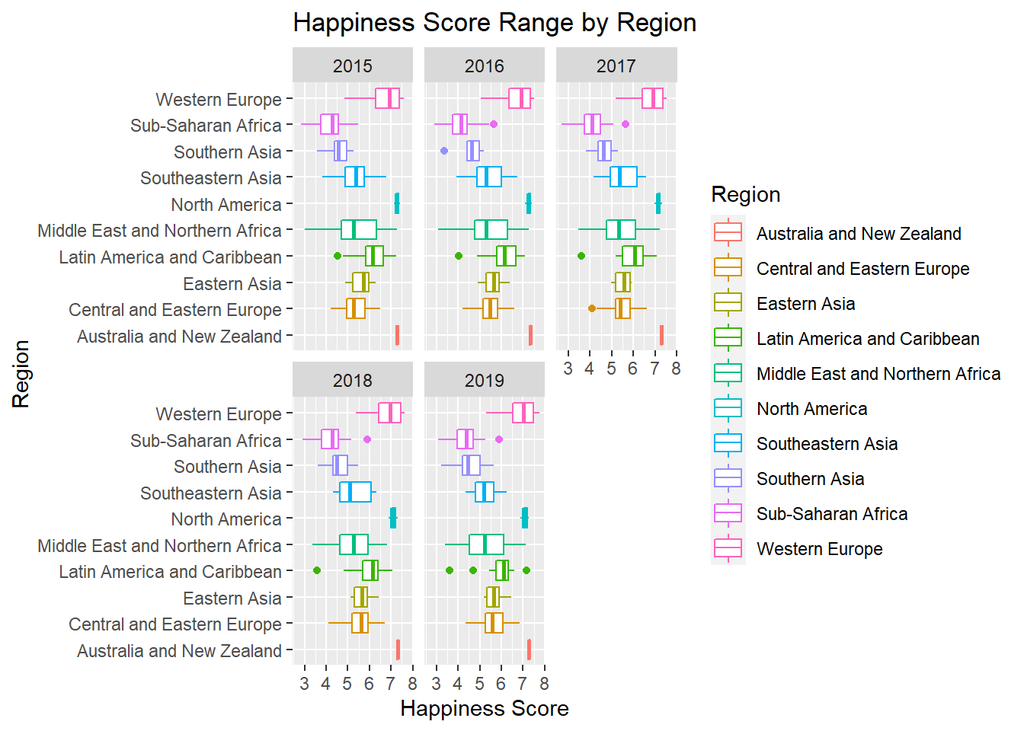

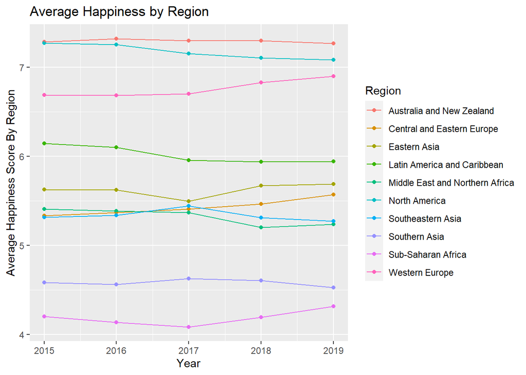

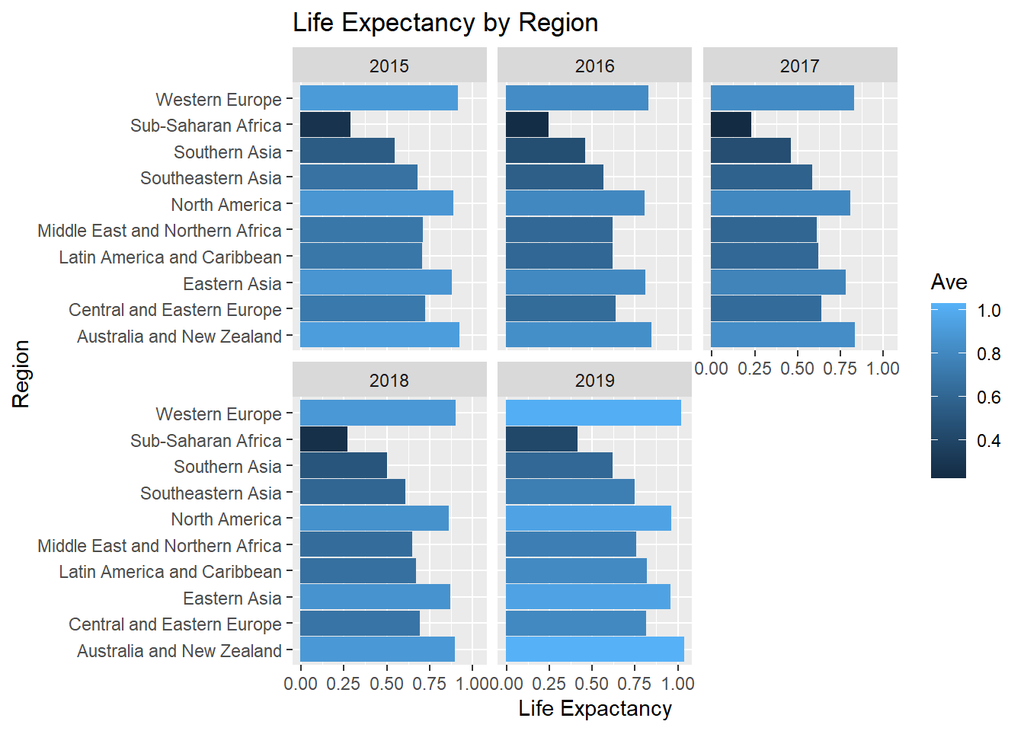

### Data Exploration

Correlation between Happiness Score and Life Expectancy

```
## [1] 0.7458976
```

```
##
## Call:
## lm(formula = `Happiness Score` ~ `Life Expectancy`, data = happiness.dataset)
##
## Residuals:
##      Min       1Q   Median       3Q      Max
## -2.74402 -0.52352  0.00054  0.56512  1.76238
##
## Coefficients:
##                   Estimate Std. Error t value Pr(>|t|)
## (Intercept)        3.28632    0.07326   44.86   <2e-16 ***
## `Life Expectancy`  3.41266    0.11054   30.87   <2e-16 ***
## ---
## Signif. codes:  0 '***' 0.001 '**' 0.01 '*' 0.05 '.' 0.1 ' ' 1
##
## Residual standard error: 0.7524 on 760 degrees of freedom
## Multiple R-squared:  0.5564, Adjusted R-squared:  0.5558
## F-statistic: 953.1 on 1 and 760 DF,  p-value: < 2.2e-16
```

Correlation between Freedom and Trust in Government

```
## [1] 0.4636301
```

```
##
## Call:
## lm(formula = Freedom ~ `Trust in Government`, data = happiness.dataset)
##
## Residuals:
##      Min       1Q   Median       3Q      Max
## -0.41903 -0.08341  0.02064  0.09324  0.32544
##
## Coefficients:
##                       Estimate Std. Error t value Pr(>|t|)
## (Intercept)           0.327334   0.007572   43.23   <2e-16 ***
## `Trust in Government` 0.665069   0.046104   14.43   <2e-16 ***
## ---
## Signif. codes:  0 '***' 0.001 '**' 0.01 '*' 0.05 '.' 0.1 ' ' 1
##
## Residual standard error: 0.1351 on 760 degrees of freedom
## Multiple R-squared:  0.215,  Adjusted R-squared:  0.2139
## F-statistic: 208.1 on 1 and 760 DF,  p-value: < 2.2e-16
```